# Risk Factor Analysis

## Outcome Variable

**Outcome Variable:** stunted

## Predictor Variables

**Intervention Variable:** nrooms

**Adjustment Set:**

- arm
- sex
- W_mage
- meducyrs
- feducyrs
- hhwealth_quart
- hfoodsec
- W_mhtcm
- W_nchldlt5
- W_parity
- impfloor
- impsan
- safeh20
- delta_W_mage
- delta_meducyrs
- delta_feducyrs
- delta_hhwealth_quart
- delta_hfoodsec
- delta_W_mhtcm
- delta_W_nchldlt5
- delta_W_parity
- delta_impfloor
- delta_impsan
- delta_safeh20

## Stratifying Variables

The analysis was stratified on these variable(s):

- agecat
- studyid
- country

## Data Summary

| agecat | studyid | country | nrooms | stunted | n_cell | n |
| --- | --- | --- | --- | --- | --- | --- |
| Birth | ki0047075b-MAL-ED | BANGLADESH | 4+ | 0 | 12 | 234 |
| Birth | ki0047075b-MAL-ED | BANGLADESH | 4+ | 1 | 0 | 234 |
| Birth | ki0047075b-MAL-ED | BANGLADESH | 1 | 0 | 116 | 234 |
| Birth | ki0047075b-MAL-ED | BANGLADESH | 1 | 1 | 28 | 234 |
| Birth | ki0047075b-MAL-ED | BANGLADESH | 2 | 0 | 42 | 234 |
| Birth | ki0047075b-MAL-ED | BANGLADESH | 2 | 1 | 8 | 234 |
| Birth | ki0047075b-MAL-ED | BANGLADESH | 3 | 0 | 26 | 234 |
| Birth | ki0047075b-MAL-ED | BANGLADESH | 3 | 1 | 2 | 234 |
| Birth | ki0047075b-MAL-ED | BRAZIL | 4+ | 0 | 93 | 174 |
| Birth | ki0047075b-MAL-ED | BRAZIL | 4+ | 1 | 9 | 174 |
| Birth | ki0047075b-MAL-ED | BRAZIL | 1 | 0 | 3 | 174 |
| Birth | ki0047075b-MAL-ED | BRAZIL | 1 | 1 | 0 | 174 |
| Birth | ki0047075b-MAL-ED | BRAZIL | 2 | 0 | 18 | 174 |
| Birth | ki0047075b-MAL-ED | BRAZIL | 2 | 1 | 1 | 174 |
| Birth | ki0047075b-MAL-ED | BRAZIL | 3 | 0 | 43 | 174 |
| Birth | ki0047075b-MAL-ED | BRAZIL | 3 | 1 | 7 | 174 |
| Birth | ki0047075b-MAL-ED | INDIA | 4+ | 0 | 20 | 191 |
| Birth | ki0047075b-MAL-ED | INDIA | 4+ | 1 | 2 | 191 |
| Birth | ki0047075b-MAL-ED | INDIA | 1 | 0 | 63 | 191 |
| Birth | ki0047075b-MAL-ED | INDIA | 1 | 1 | 6 | 191 |
| Birth | ki0047075b-MAL-ED | INDIA | 2 | 0 | 51 | 191 |
| Birth | ki0047075b-MAL-ED | INDIA | 2 | 1 | 17 | 191 |
| Birth | ki0047075b-MAL-ED | INDIA | 3 | 0 | 27 | 191 |
| Birth | ki0047075b-MAL-ED | INDIA | 3 | 1 | 5 | 191 |
| Birth | ki0047075b-MAL-ED | NEPAL | 4+ | 0 | 87 | 171 |
| Birth | ki0047075b-MAL-ED | NEPAL | 4+ | 1 | 10 | 171 |
| Birth | ki0047075b-MAL-ED | NEPAL | 1 | 0 | 33 | 171 |
| Birth | ki0047075b-MAL-ED | NEPAL | 1 | 1 | 3 | 171 |
| Birth | ki0047075b-MAL-ED | NEPAL | 2 | 0 | 20 | 171 |
| Birth | ki0047075b-MAL-ED | NEPAL | 2 | 1 | 1 | 171 |

[output cut: 338 more lines]

The following strata were considered:

- agecat: 24 months, studyid: ki0047075b-MAL-ED, country: BANGLADESH
- agecat: 24 months, studyid: ki0047075b-MAL-ED, country: BRAZIL
- agecat: 24 months, studyid: ki0047075b-MAL-ED, country: INDIA
- agecat: 24 months, studyid: ki0047075b-MAL-ED, country: NEPAL
- agecat: 24 months, studyid: ki0047075b-MAL-ED, country: PERU
- agecat: 24 months, studyid: ki0047075b-MAL-ED, country: SOUTH AFRICA
- agecat: 24 months, studyid: ki0047075b-MAL-ED, country: TANZANIA, UNITED REPUBLIC OF
- agecat: 24 months, studyid: ki1000108-CMC-V-BCS-2002, country: INDIA
- agecat: 24 months, studyid: ki1000108-IRC, country: INDIA
- agecat: 24 months, studyid: ki1017093b-PROVIDE, country: BANGLADESH
- agecat: 24 months, studyid: ki1017093c-NIH-Crypto, country: BANGLADESH
- agecat: 24 months, studyid: ki1113344-GMS-Nepal, country: NEPAL
- agecat: 24 months, studyid: ki1114097-CONTENT, country: PERU
- agecat: 24 months, studyid: ki1135781-COHORTS, country: INDIA
- agecat: 24 months, studyid: kiGH5241-JiVitA-3, country: BANGLADESH
- agecat: 24 months, studyid: kiGH5241-JiVitA-4, country: BANGLADESH
- agecat: 6 months, studyid: ki0047075b-MAL-ED, country: BANGLADESH
- agecat: 6 months, studyid: ki0047075b-MAL-ED, country: BRAZIL
- agecat: 6 months, studyid: ki0047075b-MAL-ED, country: INDIA
- agecat: 6 months, studyid: ki0047075b-MAL-ED, country: NEPAL
- agecat: 6 months, studyid: ki0047075b-MAL-ED, country: PERU
- agecat: 6 months, studyid: ki0047075b-MAL-ED, country: SOUTH AFRICA
- agecat: 6 months, studyid: ki0047075b-MAL-ED, country: TANZANIA, UNITED REPUBLIC OF
- agecat: 6 months, studyid: ki1000108-CMC-V-BCS-2002, country: INDIA
- agecat: 6 months, studyid: ki1000108-IRC, country: INDIA
- agecat: 6 months, studyid: ki1017093b-PROVIDE, country: BANGLADESH
- agecat: 6 months, studyid: ki1017093c-NIH-Crypto, country: BANGLADESH
- agecat: 6 months, studyid: ki1113344-GMS-Nepal, country: NEPAL
- agecat: 6 months, studyid: ki1114097-CONTENT, country: PERU
- agecat: 6 months, studyid: ki1135781-COHORTS, country: INDIA
- agecat: 6 months, studyid: kiGH5241-JiVitA-3, country: BANGLADESH
- agecat: 6 months, studyid: kiGH5241-JiVitA-4, country: BANGLADESH
- agecat: Birth, studyid: ki0047075b-MAL-ED, country: BANGLADESH
- agecat: Birth, studyid: ki0047075b-MAL-ED, country: BRAZIL
- agecat: Birth, studyid: ki0047075b-MAL-ED, country: INDIA
- agecat: Birth, studyid: ki0047075b-MAL-ED, country: NEPAL
- agecat: Birth, studyid: ki0047075b-MAL-ED, country: PERU
- agecat: Birth, studyid: ki0047075b-MAL-ED, country: SOUTH AFRICA
- agecat: Birth, studyid: ki0047075b-MAL-ED, country: TANZANIA, UNITED REPUBLIC OF
- agecat: Birth, studyid: ki1000108-CMC-V-BCS-2002, country: INDIA
- agecat: Birth, studyid: ki1000108-IRC, country: INDIA
- agecat: Birth, studyid: ki1017093c-NIH-Crypto, country: BANGLADESH
- agecat: Birth, studyid: ki1114097-CONTENT, country: PERU
- agecat: Birth, studyid: ki1135781-COHORTS, country: INDIA
- agecat: Birth, studyid: kiGH5241-JiVitA-3, country: BANGLADESH
- agecat: Birth, studyid: kiGH5241-JiVitA-4, country: BANGLADESH

### Dropped Strata

Some strata were dropped due to rare outcomes:

- agecat: Birth, studyid: ki0047075b-MAL-ED, country: BANGLADESH
- agecat: Birth, studyid: ki0047075b-MAL-ED, country: BRAZIL
- agecat: Birth, studyid: ki0047075b-MAL-ED, country: INDIA
- agecat: Birth, studyid: ki0047075b-MAL-ED, country: NEPAL
- agecat: Birth, studyid: ki0047075b-MAL-ED, country: PERU
- agecat: Birth, studyid: ki0047075b-MAL-ED, country: SOUTH AFRICA
- agecat: Birth, studyid: ki0047075b-MAL-ED, country: TANZANIA, UNITED REPUBLIC OF
- agecat: Birth, studyid: ki1000108-CMC-V-BCS-2002, country: INDIA
- agecat: Birth, studyid: ki1000108-IRC, country: INDIA
- agecat: Birth, studyid: ki1017093c-NIH-Crypto, country: BANGLADESH
- agecat: Birth, studyid: ki1114097-CONTENT, country: PERU
- agecat: 6 months, studyid: ki0047075b-MAL-ED, country: BANGLADESH
- agecat: 6 months, studyid: ki0047075b-MAL-ED, country: BRAZIL
- agecat: 6 months, studyid: ki0047075b-MAL-ED, country: INDIA
- agecat: 6 months, studyid: ki0047075b-MAL-ED, country: NEPAL
- agecat: 6 months, studyid: ki0047075b-MAL-ED, country: SOUTH AFRICA
- agecat: 6 months, studyid: ki0047075b-MAL-ED, country: TANZANIA, UNITED REPUBLIC OF
- agecat: 6 months, studyid: ki1000108-CMC-V-BCS-2002, country: INDIA
- agecat: 6 months, studyid: ki1000108-IRC, country: INDIA
- agecat: 6 months, studyid: ki1017093b-PROVIDE, country: BANGLADESH
- agecat: 6 months, studyid: ki1114097-CONTENT, country: PERU
- agecat: 24 months, studyid: ki0047075b-MAL-ED, country: BANGLADESH
- agecat: 24 months, studyid: ki0047075b-MAL-ED, country: BRAZIL
- agecat: 24 months, studyid: ki0047075b-MAL-ED, country: TANZANIA, UNITED REPUBLIC OF
- agecat: 24 months, studyid: ki1114097-CONTENT, country: PERU

## Methods Detail

We’re interested in the causal parameters $E[Y_a]$ for all values of $a \in \mathcal{A}$. These parameters represent the mean outcome if, possibly contrary to fact, we intervened to set all units to have $A=a$. Under the randomization and positivity assumptions, these are identified by the statistical parameters $\psi_a=E_W[E_{Y|A,W}(Y|A=a,W)]$. In addition, we’re interested in the mean of $Y$, $E[Y]$ under no intervention (the observed mean). We will estimate these parameters by using SuperLearner to fit the relevant likelihood factors – $E_{Y|A,W}(Y|A=a,W)$ and $p(A=a|W)$, and then updating our likelihood fit using a joint TMLE.

For unadjusted analyses ($W=\{\}$), initial likelihoods were estimated using Lrnr_glm to estimate the simple $E(Y|A)$ and Lrnr_mean to estimate $p(A)$. For adjusted analyses, a small library containing Lrnr_glmnet, Lrnr_xgboost, and Lrnr_mean was used.

Having estimated these parameters, we will then use the delta method to estimate relative risks and attributable risks relative to a prespecified baseline level of $A$.

# Results Detail

## Results Plots

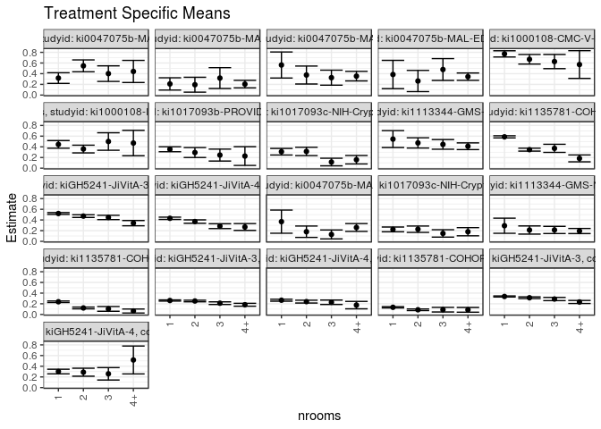

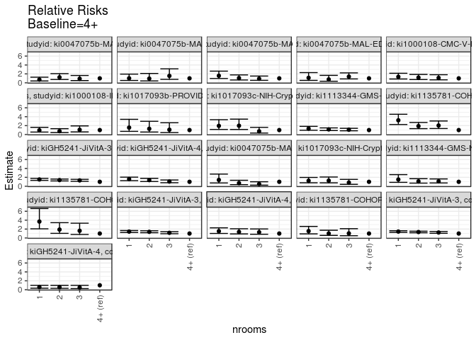

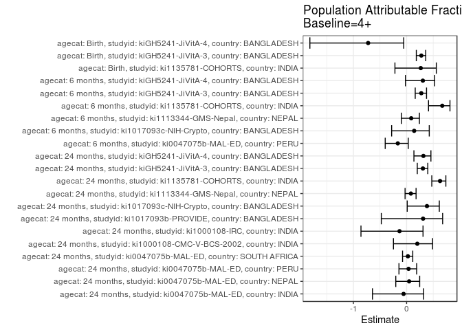

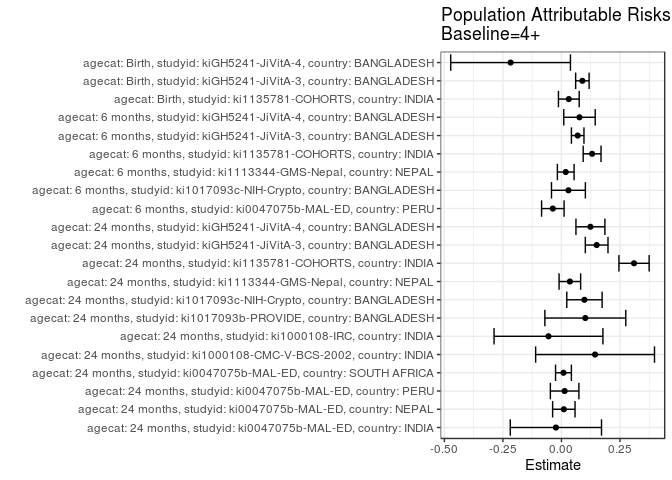

## Results Table

### Parameter: TSM

| agecat | studyid | country | intervention_level | baseline_level | estimate | ci_lower | ci_upper |
| --- | --- | --- | --- | --- | --- | --- | --- |
| Birth | ki1135781-COHORTS | INDIA | 4+ | NA | 0.0869565 | 0.0425224 | 0.1313907 |
| Birth | ki1135781-COHORTS | INDIA | 1 | NA | 0.1344000 | 0.1224401 | 0.1463599 |
| Birth | ki1135781-COHORTS | INDIA | 2 | NA | 0.0880866 | 0.0731587 | 0.1030146 |
| Birth | ki1135781-COHORTS | INDIA | 3 | NA | 0.0898204 | 0.0464507 | 0.1331901 |
| Birth | kiGH5241-JiVitA-3 | BANGLADESH | 4+ | NA | 0.2339812 | 0.2053465 | 0.2626159 |
| Birth | kiGH5241-JiVitA-3 | BANGLADESH | 1 | NA | 0.3374639 | 0.3276687 | 0.3472591 |
| Birth | kiGH5241-JiVitA-3 | BANGLADESH | 2 | NA | 0.3129518 | 0.2971312 | 0.3287723 |
| Birth | kiGH5241-JiVitA-3 | BANGLADESH | 3 | NA | 0.2893849 | 0.2592076 | 0.3195622 |
| Birth | kiGH5241-JiVitA-4 | BANGLADESH | 4+ | NA | 0.5176616 | 0.2564345 | 0.7788886 |
| Birth | kiGH5241-JiVitA-4 | BANGLADESH | 1 | NA | 0.3007129 | 0.2573370 | 0.3440889 |
| Birth | kiGH5241-JiVitA-4 | BANGLADESH | 2 | NA | 0.2882448 | 0.2135086 | 0.3629811 |
| Birth | kiGH5241-JiVitA-4 | BANGLADESH | 3 | NA | 0.2582011 | 0.1421243 | 0.3742779 |
| 6 months | ki0047075b-MAL-ED | PERU | 4+ | NA | 0.2589928 | 0.1860300 | 0.3319556 |
| 6 months | ki0047075b-MAL-ED | PERU | 1 | NA | 0.3684211 | 0.1511194 | 0.5857227 |
| 6 months | ki0047075b-MAL-ED | PERU | 2 | NA | 0.1800000 | 0.0733129 | 0.2866871 |
| 6 months | ki0047075b-MAL-ED | PERU | 3 | NA | 0.1290323 | 0.0454319 | 0.2126326 |
| 6 months | ki1017093c-NIH-Crypto | BANGLADESH | 4+ | NA | 0.1799263 | 0.1036352 | 0.2562174 |
| 6 months | ki1017093c-NIH-Crypto | BANGLADESH | 1 | NA | 0.2234023 | 0.1788469 | 0.2679578 |
| 6 months | ki1017093c-NIH-Crypto | BANGLADESH | 2 | NA | 0.2269066 | 0.1670988 | 0.2867144 |
| 6 months | ki1017093c-NIH-Crypto | BANGLADESH | 3 | NA | 0.1481167 | 0.0786806 | 0.2175528 |
| 6 months | ki1113344-GMS-Nepal | NEPAL | 4+ | NA | 0.1930548 | 0.1453009 | 0.2408087 |
| 6 months | ki1113344-GMS-Nepal | NEPAL | 1 | NA | 0.2921291 | 0.1502113 | 0.4340469 |
| 6 months | ki1113344-GMS-Nepal | NEPAL | 2 | NA | 0.2115858 | 0.1351557 | 0.2880159 |
| 6 months | ki1113344-GMS-Nepal | NEPAL | 3 | NA | 0.2129718 | 0.1456648 | 0.2802787 |
| 6 months | ki1135781-COHORTS | INDIA | 4+ | NA | 0.0645161 | 0.0270802 | 0.1019521 |
| 6 months | ki1135781-COHORTS | INDIA | 1 | NA | 0.2380952 | 0.2233666 | 0.2528239 |
| 6 months | ki1135781-COHORTS | INDIA | 2 | NA | 0.1221167 | 0.1054000 | 0.1388333 |
| 6 months | ki1135781-COHORTS | INDIA | 3 | NA | 0.1043956 | 0.0599677 | 0.1488235 |
| 6 months | kiGH5241-JiVitA-3 | BANGLADESH | 4+ | NA | 0.1820166 | 0.1549098 | 0.2091235 |
| 6 months | kiGH5241-JiVitA-3 | BANGLADESH | 1 | NA | 0.2610903 | 0.2500012 | 0.2721795 |

[output cut: 54 more lines]

### Parameter: E(Y)

| agecat | studyid | country | intervention_level | baseline_level | estimate | ci_lower | ci_upper |
| --- | --- | --- | --- | --- | --- | --- | --- |
| Birth | ki1135781-COHORTS | INDIA | NA | NA | 0.1184735 | 0.1093005 | 0.1276464 |
| Birth | kiGH5241-JiVitA-3 | BANGLADESH | NA | NA | 0.3233958 | 0.3157274 | 0.3310641 |
| Birth | kiGH5241-JiVitA-4 | BANGLADESH | NA | NA | 0.3004866 | 0.2649179 | 0.3360553 |
| 6 months | ki0047075b-MAL-ED | PERU | NA | NA | 0.2222222 | 0.1725409 | 0.2719036 |
| 6 months | ki1017093c-NIH-Crypto | BANGLADESH | NA | NA | 0.2097902 | 0.1799252 | 0.2396552 |
| 6 months | ki1113344-GMS-Nepal | NEPAL | NA | NA | 0.2113677 | 0.1776128 | 0.2451225 |
| 6 months | ki1135781-COHORTS | INDIA | NA | NA | 0.1954857 | 0.1844503 | 0.2065211 |
| 6 months | kiGH5241-JiVitA-3 | BANGLADESH | NA | NA | 0.2514286 | 0.2432985 | 0.2595587 |
| 6 months | kiGH5241-JiVitA-4 | BANGLADESH | NA | NA | 0.2522280 | 0.2381653 | 0.2662906 |
| 24 months | ki0047075b-MAL-ED | INDIA | NA | NA | 0.4185022 | 0.3541865 | 0.4828179 |
| 24 months | ki0047075b-MAL-ED | NEPAL | NA | NA | 0.2149123 | 0.1614774 | 0.2683472 |
| 24 months | ki0047075b-MAL-ED | PERU | NA | NA | 0.3681592 | 0.3013164 | 0.4350020 |
| 24 months | ki0047075b-MAL-ED | SOUTH AFRICA | NA | NA | 0.3529412 | 0.2921001 | 0.4137823 |
| 24 months | ki1000108-CMC-V-BCS-2002 | INDIA | NA | NA | 0.7150538 | 0.6691221 | 0.7609854 |
| 24 months | ki1000108-IRC | INDIA | NA | NA | 0.4152334 | 0.3673018 | 0.4631651 |
| 24 months | ki1017093b-PROVIDE | BANGLADESH | NA | NA | 0.3292894 | 0.2909105 | 0.3676684 |
| 24 months | ki1017093c-NIH-Crypto | BANGLADESH | NA | NA | 0.2568093 | 0.2190047 | 0.2946140 |
| 24 months | ki1113344-GMS-Nepal | NEPAL | NA | NA | 0.4468938 | 0.4032281 | 0.4905594 |
| 24 months | ki1135781-COHORTS | INDIA | NA | NA | 0.4934649 | 0.4774590 | 0.5094709 |
| 24 months | kiGH5241-JiVitA-3 | BANGLADESH | NA | NA | 0.4908353 | 0.4776984 | 0.5039721 |
| 24 months | kiGH5241-JiVitA-4 | BANGLADESH | NA | NA | 0.3922477 | 0.3752571 | 0.4092384 |

### Parameter: RR

| agecat | studyid | country | intervention_level | baseline_level | estimate | ci_lower | ci_upper |
| --- | --- | --- | --- | --- | --- | --- | --- |
| Birth | ki1135781-COHORTS | INDIA | 4+ | 4+ | 1.0000000 | 1.0000000 | 1.0000000 |
| Birth | ki1135781-COHORTS | INDIA | 1 | 4+ | 1.5456000 | 0.9201016 | 2.5963213 |
| Birth | ki1135781-COHORTS | INDIA | 2 | 4+ | 1.0129964 | 0.5912897 | 1.7354635 |
| Birth | ki1135781-COHORTS | INDIA | 3 | 4+ | 1.0329341 | 0.5113859 | 2.0863949 |
| Birth | kiGH5241-JiVitA-3 | BANGLADESH | 4+ | 4+ | 1.0000000 | 1.0000000 | 1.0000000 |
| Birth | kiGH5241-JiVitA-3 | BANGLADESH | 1 | 4+ | 1.4422692 | 1.2700961 | 1.6377820 |
| Birth | kiGH5241-JiVitA-3 | BANGLADESH | 2 | 4+ | 1.3375080 | 1.1746859 | 1.5228988 |
| Birth | kiGH5241-JiVitA-3 | BANGLADESH | 3 | 4+ | 1.2367867 | 1.0515566 | 1.4546447 |
| Birth | kiGH5241-JiVitA-4 | BANGLADESH | 4+ | 4+ | 1.0000000 | 1.0000000 | 1.0000000 |
| Birth | kiGH5241-JiVitA-4 | BANGLADESH | 1 | 4+ | 0.5809065 | 0.3422161 | 0.9860794 |
| Birth | kiGH5241-JiVitA-4 | BANGLADESH | 2 | 4+ | 0.5568210 | 0.3171031 | 0.9777565 |
| Birth | kiGH5241-JiVitA-4 | BANGLADESH | 3 | 4+ | 0.4987836 | 0.2532817 | 0.9822464 |
| 6 months | ki0047075b-MAL-ED | PERU | 4+ | 4+ | 1.0000000 | 1.0000000 | 1.0000000 |
| 6 months | ki0047075b-MAL-ED | PERU | 1 | 4+ | 1.4225146 | 0.7399163 | 2.7348335 |
| 6 months | ki0047075b-MAL-ED | PERU | 2 | 4+ | 0.6950000 | 0.3605609 | 1.3396490 |
| 6 months | ki0047075b-MAL-ED | PERU | 3 | 4+ | 0.4982079 | 0.2457997 | 1.0098104 |
| 6 months | ki1017093c-NIH-Crypto | BANGLADESH | 4+ | 4+ | 1.0000000 | 1.0000000 | 1.0000000 |
| 6 months | ki1017093c-NIH-Crypto | BANGLADESH | 1 | 4+ | 1.2416323 | 0.7778980 | 1.9818162 |
| 6 months | ki1017093c-NIH-Crypto | BANGLADESH | 2 | 4+ | 1.2611087 | 0.7664969 | 2.0748880 |
| 6 months | ki1017093c-NIH-Crypto | BANGLADESH | 3 | 4+ | 0.8232077 | 0.4376075 | 1.5485815 |
| 6 months | ki1113344-GMS-Nepal | NEPAL | 4+ | 4+ | 1.0000000 | 1.0000000 | 1.0000000 |
| 6 months | ki1113344-GMS-Nepal | NEPAL | 1 | 4+ | 1.5131924 | 0.8767489 | 2.6116387 |
| 6 months | ki1113344-GMS-Nepal | NEPAL | 2 | 4+ | 1.0959883 | 0.7070074 | 1.6989786 |
| 6 months | ki1113344-GMS-Nepal | NEPAL | 3 | 4+ | 1.1031673 | 0.7386932 | 1.6474744 |
| 6 months | ki1135781-COHORTS | INDIA | 4+ | 4+ | 1.0000000 | 1.0000000 | 1.0000000 |
| 6 months | ki1135781-COHORTS | INDIA | 1 | 4+ | 3.6904762 | 2.0589789 | 6.6147422 |
| 6 months | ki1135781-COHORTS | INDIA | 2 | 4+ | 1.8928087 | 1.0427652 | 3.4357925 |
| 6 months | ki1135781-COHORTS | INDIA | 3 | 4+ | 1.6181319 | 0.7879522 | 3.3229819 |
| 6 months | kiGH5241-JiVitA-3 | BANGLADESH | 4+ | 4+ | 1.0000000 | 1.0000000 | 1.0000000 |
| 6 months | kiGH5241-JiVitA-3 | BANGLADESH | 1 | 4+ | 1.4344312 | 1.2308510 | 1.6716832 |

[output cut: 54 more lines]

### Parameter: PAR

| agecat | studyid | country | intervention_level | baseline_level | estimate | ci_lower | ci_upper |
| --- | --- | --- | --- | --- | --- | --- | --- |
| Birth | ki1135781-COHORTS | INDIA | 4+ | NA | 0.0315170 | -0.0127529 | 0.0757868 |
| Birth | kiGH5241-JiVitA-3 | BANGLADESH | 4+ | NA | 0.0894146 | 0.0606495 | 0.1181796 |
| Birth | kiGH5241-JiVitA-4 | BANGLADESH | 4+ | NA | -0.2171750 | -0.4728173 | 0.0384674 |
| 6 months | ki0047075b-MAL-ED | PERU | 4+ | NA | -0.0367706 | -0.0848383 | 0.0112971 |
| 6 months | ki1017093c-NIH-Crypto | BANGLADESH | 4+ | NA | 0.0298639 | -0.0425077 | 0.1022355 |
| 6 months | ki1113344-GMS-Nepal | NEPAL | 4+ | NA | 0.0183128 | -0.0173396 | 0.0539653 |
| 6 months | ki1135781-COHORTS | INDIA | 4+ | NA | 0.1309696 | 0.0928493 | 0.1690899 |
| 6 months | kiGH5241-JiVitA-3 | BANGLADESH | 4+ | NA | 0.0694119 | 0.0425945 | 0.0962294 |
| 6 months | kiGH5241-JiVitA-4 | BANGLADESH | 4+ | NA | 0.0770454 | 0.0098835 | 0.1442074 |
| 24 months | ki0047075b-MAL-ED | INDIA | 4+ | NA | -0.0236972 | -0.2184888 | 0.1710943 |
| 24 months | ki0047075b-MAL-ED | NEPAL | 4+ | NA | 0.0101879 | -0.0376789 | 0.0580546 |
| 24 months | ki0047075b-MAL-ED | PERU | 4+ | NA | 0.0136137 | -0.0472857 | 0.0745132 |
| 24 months | ki0047075b-MAL-ED | SOUTH AFRICA | 4+ | NA | 0.0086789 | -0.0251192 | 0.0424769 |
| 24 months | ki1000108-CMC-V-BCS-2002 | INDIA | 4+ | NA | 0.1436252 | -0.1101796 | 0.3974300 |
| 24 months | ki1000108-IRC | INDIA | 4+ | NA | -0.0553548 | -0.2877729 | 0.1770633 |
| 24 months | ki1017093b-PROVIDE | BANGLADESH | 4+ | NA | 0.1020167 | -0.0707519 | 0.2747853 |
| 24 months | ki1017093c-NIH-Crypto | BANGLADESH | 4+ | NA | 0.0982728 | 0.0228208 | 0.1737247 |
| 24 months | ki1113344-GMS-Nepal | NEPAL | 4+ | NA | 0.0359234 | -0.0100932 | 0.0819400 |
| 24 months | ki1135781-COHORTS | INDIA | 4+ | NA | 0.3100258 | 0.2454563 | 0.3745954 |
| 24 months | kiGH5241-JiVitA-3 | BANGLADESH | 4+ | NA | 0.1503924 | 0.1019902 | 0.1987946 |
| 24 months | kiGH5241-JiVitA-4 | BANGLADESH | 4+ | NA | 0.1237772 | 0.0619680 | 0.1855863 |

### Parameter: PAF

| agecat | studyid | country | intervention_level | baseline_level | estimate | ci_lower | ci_upper |
| --- | --- | --- | --- | --- | --- | --- | --- |
| Birth | ki1135781-COHORTS | INDIA | 4+ | NA | 0.2660254 | -0.2191932 | 0.5581351 |
| Birth | kiGH5241-JiVitA-3 | BANGLADESH | 4+ | NA | 0.2764865 | 0.1826847 | 0.3595227 |
| Birth | kiGH5241-JiVitA-4 | BANGLADESH | 4+ | NA | -0.7227442 | -1.8174281 | -0.0533889 |
| 6 months | ki0047075b-MAL-ED | PERU | 4+ | NA | -0.1654676 | -0.4018717 | 0.0310705 |
| 6 months | ki1017093c-NIH-Crypto | BANGLADESH | 4+ | NA | 0.1423513 | -0.2810383 | 0.4258085 |
| 6 months | ki1113344-GMS-Nepal | NEPAL | 4+ | NA | 0.0866398 | -0.0983981 | 0.2405059 |
| 6 months | ki1135781-COHORTS | INDIA | 4+ | NA | 0.6699701 | 0.4116068 | 0.8148861 |
| 6 months | kiGH5241-JiVitA-3 | BANGLADESH | 4+ | NA | 0.2760702 | 0.1619188 | 0.3746735 |
| 6 months | kiGH5241-JiVitA-4 | BANGLADESH | 4+ | NA | 0.3054595 | -0.0217043 | 0.5278609 |
| 24 months | ki0047075b-MAL-ED | INDIA | 4+ | NA | -0.0566239 | -0.6411001 | 0.3196917 |
| 24 months | ki0047075b-MAL-ED | NEPAL | 4+ | NA | 0.0474048 | -0.2033251 | 0.2458916 |
| 24 months | ki0047075b-MAL-ED | PERU | 4+ | NA | 0.0369779 | -0.1435142 | 0.1889812 |
| 24 months | ki0047075b-MAL-ED | SOUTH AFRICA | 4+ | NA | 0.0245902 | -0.0760360 | 0.1158062 |
| 24 months | ki1000108-CMC-V-BCS-2002 | INDIA | 4+ | NA | 0.2008593 | -0.2471023 | 0.4879122 |
| 24 months | ki1000108-IRC | INDIA | 4+ | NA | -0.1333101 | -0.8573392 | 0.3084775 |
| 24 months | ki1017093b-PROVIDE | BANGLADESH | 4+ | NA | 0.3098086 | -0.4752316 | 0.6770920 |
| 24 months | ki1017093c-NIH-Crypto | BANGLADESH | 4+ | NA | 0.3826681 | 0.0113978 | 0.6145076 |
| 24 months | ki1113344-GMS-Nepal | NEPAL | 4+ | NA | 0.0803846 | -0.0287429 | 0.1779361 |
| 24 months | ki1135781-COHORTS | INDIA | 4+ | NA | 0.6282632 | 0.4732474 | 0.7376601 |
| 24 months | kiGH5241-JiVitA-3 | BANGLADESH | 4+ | NA | 0.3064009 | 0.2005610 | 0.3982284 |
| 24 months | kiGH5241-JiVitA-4 | BANGLADESH | 4+ | NA | 0.3155587 | 0.1376638 | 0.4567549 |